# Text Mining of Parks and Recreation

Elliott Tran

12/20/2019

## Introduction

I am using text mining techniques to analyze one of my favorite shows, Parks and Recreation. I am interested in finding reoccurring themes through the show’s seven season run by utilizing the following techniques Latent Dirichlet Allocation (LDA), sentiment analysis, term-frequency inverse document frequency analysis and hierarchical clustering. Through deploying these four distinct techniques, I hope to see which one is most helpful in gaining insights on the show.

## The Data

The dataset was taken from [Kaggle](https://www.kaggle.com/heheheluke/parks-and-recreation-scripts). Kaggle user Luke He compiled the transcripts from [Springfield! Springfield!](https://www.springfieldspringfield.co.uk/episode_scripts.php?tv-show=parks-and-recreation) and labeled it manually. Transcripts were split into episodes with a column for character name and a column for line spoken.

There is a total of 122 CSV files for this dataset although the show has a total 125 episodes formally. This is because episodes that are labeled as part 1 and part 2 were merged into one file. Accents or special characters were not included in the transcripts.

```r
#clear memory
rm(list = ls())
```

```r
#load packages
devtools::install_github("bmewing/mgsub")
library(Matrix)
library(ggplot2)
library(plyr)
library(NLP)
library(tidytext)
library(tidyverse)
library(tm)
library(wordcloud)
library(readr)
library(stringr)
library(topicmodels)
library(textdata)
library(gsubfn)
library(dplyr)
```

## Tidying with Tidyverse

I first tidy up the text using the TidyVerse library to gain general understanding of the data set and to do some preliminary analysis.

```r
#loading dataset
mydir <- "~/QMSS/Data Mining/Final Project/pandr"
#download at https://www.kaggle.com/heheheluke/parks-and-recreation-scripts
myfiles <- list.files(path=mydir, pattern="*.csv", full.names=TRUE)

pandr <- tibble(File = myfiles) %>%
    extract(File, "episode",
            "([a-z][0-9][a-z][0-9]{2})",
            remove = FALSE) %>%
    extract(File, "season",
            "([s][0-9])",
            remove = FALSE) %>%#added regular expression for file name
    mutate(Data = lapply(File, read_csv)) %>%
    unnest(Data) %>%
    select(-File)

pandr <- na.omit(pandr)
```

```r
#Unnest tokens and remove stop words
pandr_tidy <- pandr %>%
  group_by(episode) %>%
  mutate(linenumber = row_number()) %>%
  ungroup() %>%
  unnest_tokens('word', 'Line') %>%
  anti_join(stop_words)%>%
  na.omit()
head(pandr_tidy)
```

```
## # A tibble: 6 x 5
##   season episode Character    linenumber word
##   <chr>  <chr>   <chr>             <int> <chr>
## 1 s1     s1e01   Leslie Knope          3 leslie
## 2 s1     s1e01   Leslie Knope          3 knope
## 3 s1     s1e01   Leslie Knope          3 parks
## 4 s1     s1e01   Leslie Knope          3 recreation
## 5 s1     s1e01   Leslie Knope          3 department
## 6 s1     s1e01   Leslie Knope          4 questions
```

```r
#count and sort words spoken
pandr_tidy %>%
  count(word, sort = TRUE) %>%
  top_n(10)
```

```
## # A tibble: 10 x 2
##    word       n
##    <chr>  <int>
##  1 yeah    1754
##  2 gonna   1401
##  3 leslie  1313
##  4 hey     1272
##  5 ron      902
##  6 time     896
##  7 god      751
##  8 love     728
##  9 people   713
## 10 pawnee   695
```

```r
#count and sort words spoken by character
pandr_tidy %>%
  count(Character, sort = TRUE) %>%
  top_n(6)
```

```
## # A tibble: 6 x 2
##   Character         n
##   <chr>         <int>
## 1 Leslie Knope  38646
## 2 Tom Haverford 14026
## 3 Ron Swanson   11063
## 4 Andy Dwyer    10412
## 5 Ben Wyatt      9860
## 6 Ann Perkins    7224
```

```r
#count and sort words spoken per season
pandr_tidy %>%
  count(season, sort = FALSE)
```

```
## # A tibble: 7 x 2
##   season     n
##   <chr>  <int>
## 1 s1      5934
## 2 s2     24459
## 3 s3     16976
## 4 s4     23720
## 5 s5     25577
## 6 s6     25900
## 7 s7     14571
```

## Sentiment Analysis

I analyzed sentiment of the show using different sentiment lexicons and by different categories (character, season, overall).

```r
#Join sentiment lexicon with dataset
pandr_sentiment <- pandr_tidy %>%
  inner_join(get_sentiments("bing")) %>%
  count(season, episode, Character,
        index = linenumber %/% 10, sentiment) %>%
  spread(sentiment, n, fill = 0) %>%
  mutate(sentiment = positive - negative)
```

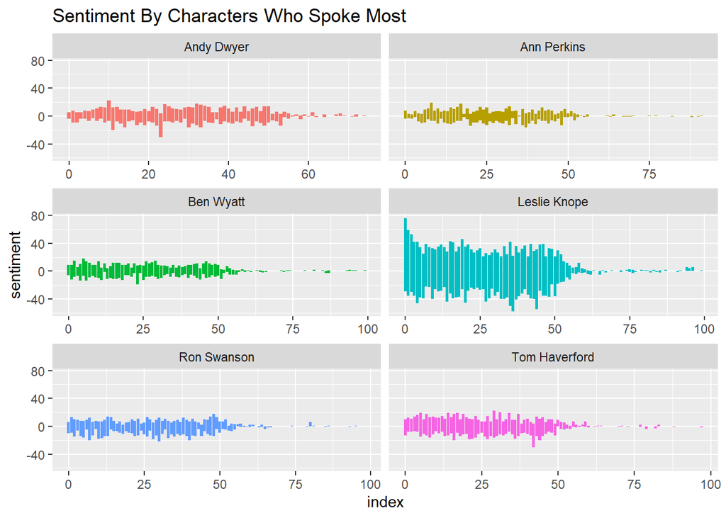

```r
#analyze sentiment of the six characters who spoke the most
pandr_sentiment %>%
  subset(Character %in% c("Leslie Knope", "Ben Wyatt",
                          "Tom Haverford", "Ron Swanson",
                          "Andy Dwyer", "Ann Perkins")) %>%
  ggplot(aes(index, sentiment, fill = Character)) +
           geom_col(show.legend = FALSE) +
           facet_wrap(~Character, ncol = 2, scales = "free_x") +
           ggtitle("Sentiment By Characters Who Spoke Most")
```

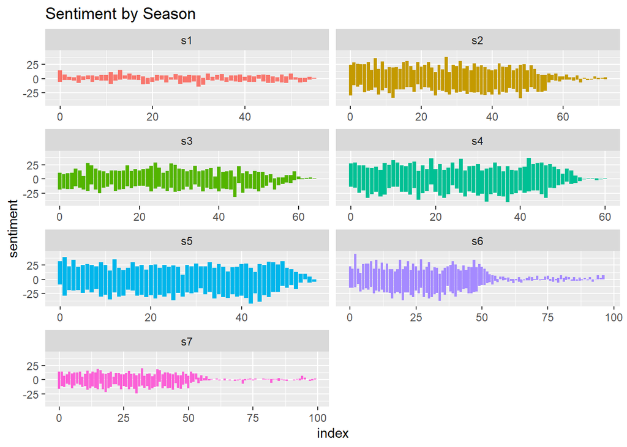

```r
#Analyze sentiment by season
pandr_sentiment %>%
  ggplot(aes(index, sentiment, fill = season)) +
           geom_col(show.legend = FALSE) +
           facet_wrap(~season, ncol = 2, scales = "free_x")+
           ggtitle("Sentiment by Season")
```

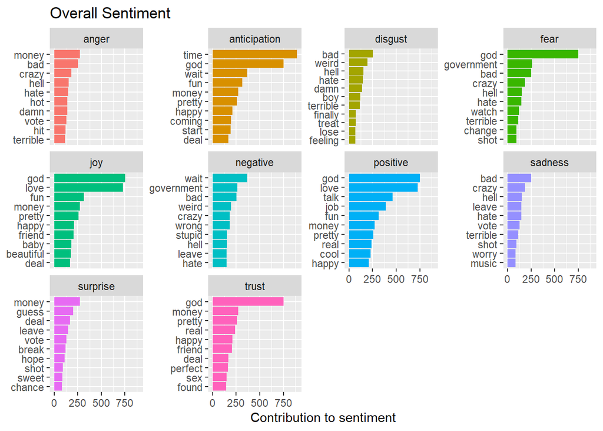

```r
#Analyze overall sentiment using NRC lexicon
pandr_tidy %>%
  inner_join(get_sentiments("nrc")) %>%
  count(word, sentiment, sort = TRUE) %>%
  ungroup() %>%
  group_by(sentiment) %>%
  top_n(10) %>%
  ungroup() %>%
  mutate(word = reorder(word, n)) %>%
  ggplot(aes(word, n, fill = sentiment)) +
  geom_col(show.legend = FALSE) +
  facet_wrap(~sentiment, scales = "free_y") +
  labs(y = "Contribution to sentiment",
       x = NULL) +
  coord_flip() +
  ggtitle("Overall Sentiment")
```

# Word Frequency

I then turned my dataset into document term matrix (DTM) to analyze the term frequency–inverse document frequency of the show to find important words to an episode or season. I also plotted the frequency of words spoken by the show’s main character, Leslie Knope, that fans generally associate with her. The graph is not filtered to be just words spoken by Leslie to see the overall occurrence of the words over the show’s seven season run.

```r
#turn dataframe into document term matrix
pandr_dtm <- pandr %>%
  unnest_tokens('word', 'Line') %>%
  anti_join(stop_words)%>%
  count(episode, word) %>%
  cast_dtm(episode, word, n)
is.list(pandr_dtm) #turn dtm into list
```

```
## [1] TRUE
```

```r
#tidy dtm
pandr_tidy2 <- tidy(pandr_dtm)
```

```r
#analyze term frequency–inverse document frequency (tfidf)
pandr_tidy_tfidf <- pandr_tidy2 %>%
  bind_tf_idf(term, document, count)

pandr_tidy_tfidf %>%
  select(-count) %>%
  arrange(desc(tf_idf)) %>%
  top_n(10)
```

```
## # A tibble: 10 x 5
##    document term         tf   idf tf_idf
##    <chr>    <chr>     <dbl> <dbl>  <dbl>
##  1 s2e18    possum   0.0299  4.11 0.123
##  2 s6e02    grid     0.0275  4.11 0.113
##  3 s3e03    twilight 0.0251  4.11 0.103
##  4 s2e10    boola    0.0208  4.80 0.100
##  5 s3e03    capsule  0.0197  4.80 0.0946
##  6 s6e17    prom     0.0265  3.42 0.0907
##  7 s2e06    kaboom   0.0186  4.80 0.0895
##  8 s2e14    justin   0.0256  3.19 0.0819
##  9 s5e06    quilt    0.0163  4.80 0.0784
## 10 s7e03    harrison 0.0179  4.11 0.0737
```

```r
#Create season counts to see key Leslie words
season_counts <- pandr_tidy2 %>%
  extract(document, "season", "([s][0-9])", convert = TRUE) %>%
  complete(season, term, fill = list(count = 0)) %>%
  group_by(season) %>%
  mutate(season_total = sum(count))
```

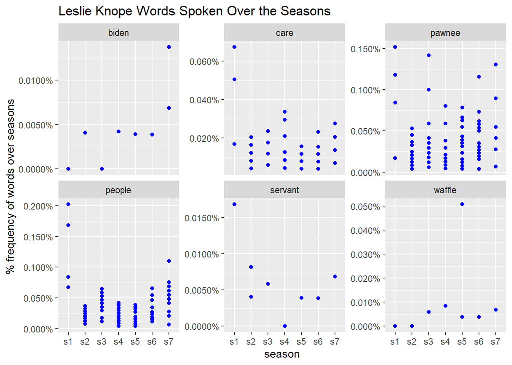

```r
season_counts %>%
  filter(term %in% c("waffle", "servant", "pawnee", "biden", "people", "care")) %>%
  ggplot(aes(season, count / season_total)) +
  geom_point(colour = "blue") +
  facet_wrap(~ term, scales = "free_y") +
  scale_y_continuous(labels = scales::percent_format()) +
  ylab("% frequency of words over seasons")+
  ggtitle("Leslie Knope Words Spoken Over the Seasons")
```

# Latent Dirichlet Allocation (LDA)

I used the Latent Dirichlet allocation topic modeling algorithm for per-topic-per-word probabilities and visualized it. It turns out that both topics have the same common words. I then looked at the beta spread to see which words have the greatest difference in beta between topic 1 and topic 2.

```r
#turn dtm into LDA
pandr_lda <- LDA(pandr_dtm, k = 2, control = list(seed = 12202019))
```

```r
pandr_topics <- tidy(pandr_lda, matrix = "beta")
```

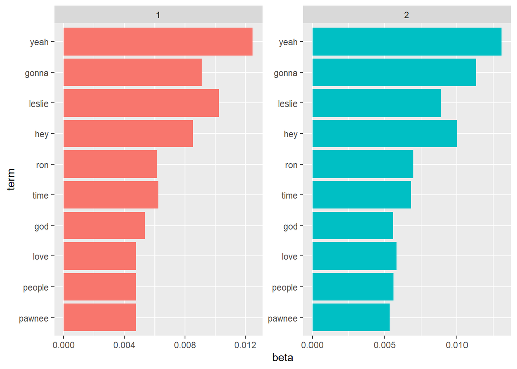

```r
#top common words of the two topics
pandr_top_terms <- pandr_topics %>%
  group_by(topic) %>%
  top_n(10, beta) %>%
  ungroup() %>%
  arrange(topic, -beta)

pandr_top_terms %>%
  mutate(term = reorder(term, beta)) %>%
  ggplot(aes(term, beta, fill = factor(topic))) +
  geom_col(show.legend = FALSE) +
  facet_wrap(~ topic, scales = "free") +
  coord_flip()
```

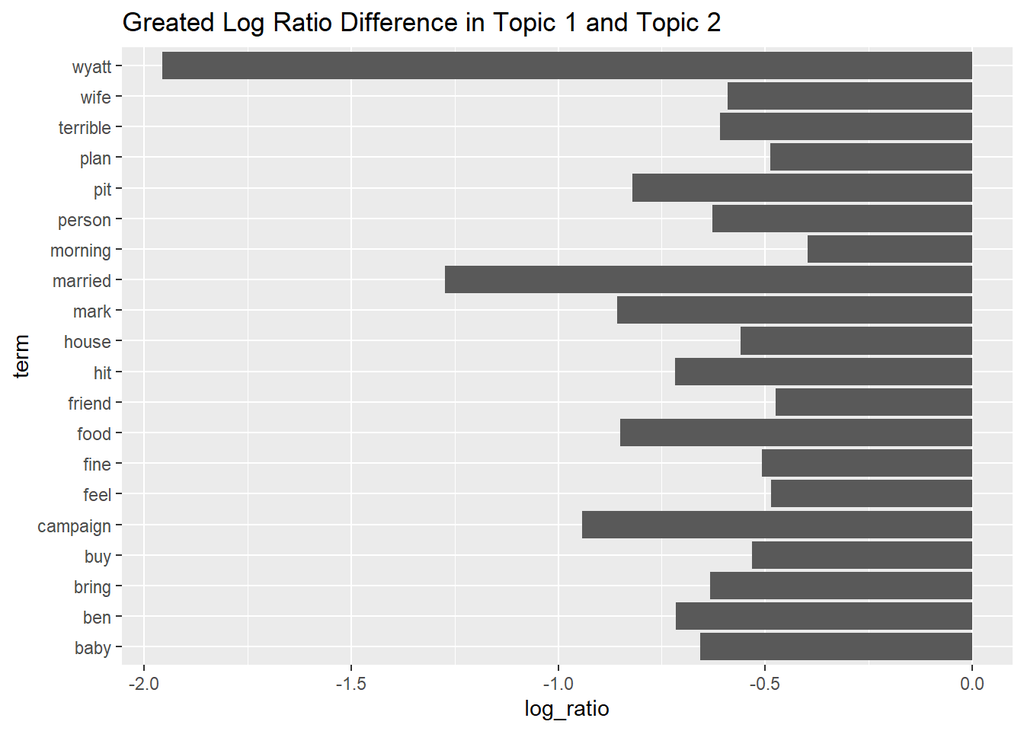

```r
#look at difference in beta between the two topics
beta_spread <- pandr_topics %>%
  mutate(topic = paste0("topic", topic)) %>%
  spread(topic, beta) %>%
  filter(topic1 > .001 | topic2 > .001) %>%
  mutate(log_ratio = log2(topic2 / topic1)) %>%
  top_n(20, desc(log_ratio))

beta_spread  %>%
  ggplot(aes(term, log_ratio)) +
  geom_col(show.legend = FALSE) +
  coord_flip() +
  ggtitle("Greated Log Ratio Difference in Topic 1 and Topic 2")
```

# Hierarchical Clustering

Lastly, I used hierarchical clustering to see linkages between episodes throughout the seasons.

```r
hc_complete <- hclust(dist(pandr_dtm), method = "complete")
hc_average <- hclust(dist(pandr_dtm), method = "average")
hc_single <- hclust(dist(pandr_dtm), method = "single")
```

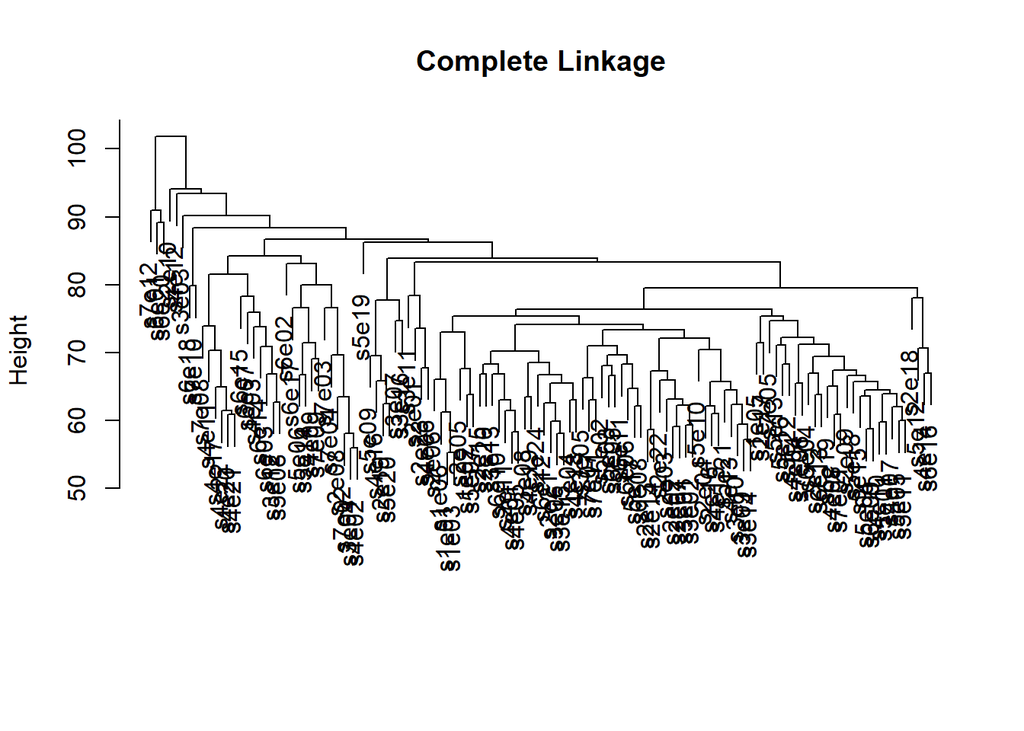

```r
plot(hc_complete, main = "Complete Linkage", xlab = "", sub = "")
```

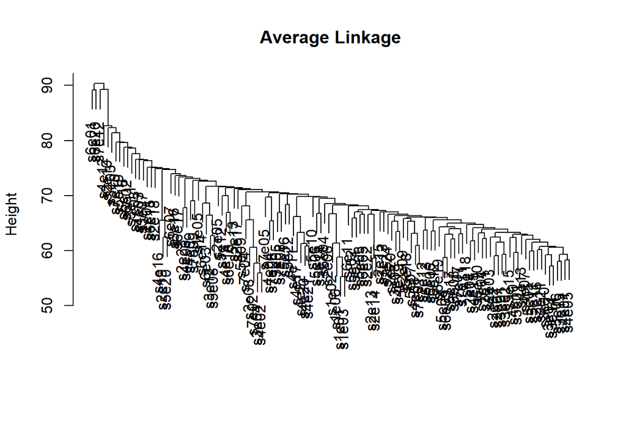

```r
plot(hc_average, main = "Average Linkage", xlab = "", sub = "")
```

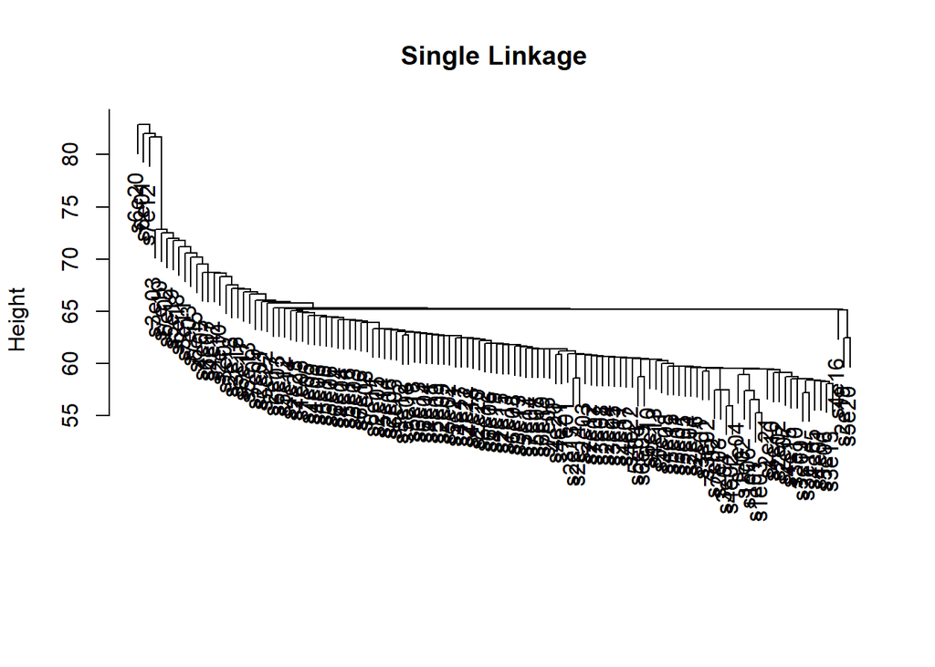

```r
plot(hc_single, main = "Single Linkage", xlab = "", sub = "")
```

# Conclusion

Overall, the results from text mining did not give clear insights into the show. I found preliminary analysis using TidyVerse to be the most helpful in understanding surface level key words and characters in the series. I also found term frequency–inverse document frequency to be fruitful. For example, TFIDF identified “possum” to be a key word in season 2 episode 18 and the episode is about just that – Leslie trying to catch a possum that bit the mayor’s dog. It also identified “twilight” as the key word for season 3 episode 3 and the book Twilight was essentially what spearheaded Leslie’s time capsule community meeting.

While sentiment analysis gave the illusion of insight, it did not account for nuances in the English language. The show is known for its playful and witty banter that did not translate well with the sentiment lexicons utilized. For example, “god” was identified as a key word for many categories in the “NRC” sentiment lexicon. However, the show is not particularly religious. When the word “god” is use in the show, it is usually used in vain.

Lastly, topic modeling and hierarchical clustering were not particularly helpful. Perhaps this has to do with the nature of the show, and therefore the dataset, as the show is meant to be viewed chronologically. For example, using hierarchical clustering to indicate which episodes are more closely align with one another is less helpful than just watching the show in order of release.